# R Notebook

# Dates and Times

```r
library(lubridate)
library(nycflights13)
library(dplyr)
library(ggplot2)
```

Let’s work with the flights dataset:

```r
flights %>%
  select(year, month, day, hour, minute)
```

```
# A tibble: 336,776 x 5
    year month   day  hour minute
   <int> <int> <int> <dbl>  <dbl>
1   2013     1     1     5     15
2   2013     1     1     5     29
3   2013     1     1     5     40
4   2013     1     1     5     45
5   2013     1     1     6      0
6   2013     1     1     5     58
7   2013     1     1     6      0
8   2013     1     1     6      0
9   2013     1     1     6      0
10  2013     1     1     6      0
# ... with 336,766 more rows
```

```r
datetimes %>%
  select(year, month, day, hour, minute, departure)
```

```
# A tibble: 336,776 x 6
    year month   day  hour minute           departure
   <int> <int> <int> <dbl>  <dbl>              <time>
1   2013     1     1     5     15 2013-01-01 05:15:00
2   2013     1     1     5     29 2013-01-01 05:29:00
3   2013     1     1     5     40 2013-01-01 05:40:00
4   2013     1     1     5     45 2013-01-01 05:45:00
5   2013     1     1     6      0 2013-01-01 06:00:00
6   2013     1     1     5     58 2013-01-01 05:58:00
7   2013     1     1     6      0 2013-01-01 06:00:00
8   2013     1     1     6      0 2013-01-01 06:00:00
9   2013     1     1     6      0 2013-01-01 06:00:00
10  2013     1     1     6      0 2013-01-01 06:00:00
# ... with 336,766 more rows
```

```r
flights %>%
  select(arr_time)
```

```
# A tibble: 336,776 x 1
   arr_time
      <int>
1       830
2       850
3       923
4      1004
5       812
6       740
7       913
8       709
9       838
10      753
# ... with 336,766 more rows
```

With a little work, we can also create arrival times for each flight in flights. I’ll then clean up the data a little.

```r
(datetimes <- datetimes %>%
  mutate(arrival = make_datetime(
    year = year,
    month = month,
    day = day,
    hour = arr_time %/% 100,
    min =  arr_time %% 100
  )) %>%
  filter(!is.na(departure), !is.na(arrival)) %>%
  select(
    departure, arrival, dep_delay, arr_delay, carrier, tailnum,
    flight, origin, dest, air_time, distance
  )
)
```

```
# A tibble: 328,063 x 11
             departure             arrival dep_delay arr_delay carrier tailnum flight origin  dest air_time distance
                <time>              <time>     <dbl>     <dbl>   <chr>   <chr>  <int>  <chr> <chr>    <dbl>    <dbl>
1  2013-01-01 05:15:00 2013-01-01 08:30:00         2        11      UA  N14228   1545    EWR   IAH      227     1400
2  2013-01-01 05:29:00 2013-01-01 08:50:00         4        20      UA  N24211   1714    LGA   IAH      227     1416
3  2013-01-01 05:40:00 2013-01-01 09:23:00         2        33      AA  N619AA   1141    JFK   MIA      160     1089
4  2013-01-01 05:45:00 2013-01-01 10:04:00        -1       -18      B6  N804JB    725    JFK   BQN      183     1576
5  2013-01-01 06:00:00 2013-01-01 08:12:00        -6       -25      DL  N668DN    461    LGA   ATL      116      762
6  2013-01-01 05:58:00 2013-01-01 07:40:00        -4        12      UA  N39463   1696    EWR   ORD      150      719
7  2013-01-01 06:00:00 2013-01-01 09:13:00        -5        19      B6  N516JB    507    EWR   FLL      158     1065
8  2013-01-01 06:00:00 2013-01-01 07:09:00        -3       -14      EV  N829AS   5708    LGA   IAD       53      229
9  2013-01-01 06:00:00 2013-01-01 08:38:00        -3        -8      B6  N593JB     79    JFK   MCO      140      944
10 2013-01-01 06:00:00 2013-01-01 07:53:00        -2         8      AA  N3ALAA    301    LGA   ORD      138      733
# ... with 328,053 more rows
```

To parse character strings as dates, identify the order in which the year, month, and day appears in your dates. Now arrange “y”, “m”, and “d” in the same order. This is the name of the function in lubridate that will parse your dates. For example,

```r
dmy("31-1-2017")
```

```
[1] "2017-01-31"
```

R now recognizes that our departure and arrival variables contain datetime information, and it saves the variables in the POSIXct format, a common way of representing dates and times. The POSIXct format has many advantages. You can display the same date time in any time zone by changing its tzone attribute (more on that later), and R can recognize when two times displayed in two different time zones refer to the same moment.

Best of all, you can change a datetime by adding or subtracting seconds from it.

This gives us a way to calculate the scheduled departure and arrival times of each flight in flights.

```r
datetimes %>%
  mutate(scheduled_departure = departure - dep_delay * 60,
         scheduled_arrival = arrival - arr_delay * 60) %>%
  select(scheduled_departure, dep_delay, departure,
         scheduled_arrival, arr_delay, arrival)
```

```
# A tibble: 328,063 x 6
   scheduled_departure dep_delay           departure   scheduled_arrival arr_delay             arrival
                <time>     <dbl>              <time>              <time>     <dbl>              <time>
1  2013-01-01 05:13:00         2 2013-01-01 05:15:00 2013-01-01 08:19:00        11 2013-01-01 08:30:00
2  2013-01-01 05:25:00         4 2013-01-01 05:29:00 2013-01-01 08:30:00        20 2013-01-01 08:50:00
3  2013-01-01 05:38:00         2 2013-01-01 05:40:00 2013-01-01 08:50:00        33 2013-01-01 09:23:00
4  2013-01-01 05:46:00        -1 2013-01-01 05:45:00 2013-01-01 10:22:00       -18 2013-01-01 10:04:00
5  2013-01-01 06:06:00        -6 2013-01-01 06:00:00 2013-01-01 08:37:00       -25 2013-01-01 08:12:00
6  2013-01-01 06:02:00        -4 2013-01-01 05:58:00 2013-01-01 07:28:00        12 2013-01-01 07:40:00
7  2013-01-01 06:05:00        -5 2013-01-01 06:00:00 2013-01-01 08:54:00        19 2013-01-01 09:13:00
8  2013-01-01 06:03:00        -3 2013-01-01 06:00:00 2013-01-01 07:23:00       -14 2013-01-01 07:09:00
9  2013-01-01 06:03:00        -3 2013-01-01 06:00:00 2013-01-01 08:46:00        -8 2013-01-01 08:38:00
10 2013-01-01 06:02:00        -2 2013-01-01 06:00:00 2013-01-01 07:45:00         8 2013-01-01 07:53:00
# ... with 328,053 more rows
```

## Difftimes

A difftime class object records a span of time in one of seconds, minutes, hours, days, or weeks. R creates a difftime whenever you subtract two dates or two datetimes.

```r
(day1 <- ymd("2000-01-01") - ymd("1999-12-31"))
```

```
Time difference of 1 days
```

Durations behave like difftimes, but are a little more user friendly. To make a duration, choose a unit of time, make it plural, and then place a “d” in front of it.

```r
dyears(1)
```

```
[1] "31536000s (~365 days)"
```

A better, and clearer way to do arithmetic with dates and times:

```r
(datetimes <- datetimes %>%
  mutate(scheduled_departure = departure - dminutes(dep_delay),
         scheduled_arrival = arrival - dminutes(arr_delay)) %>%
  select(scheduled_departure, dep_delay, departure,
         scheduled_arrival, arr_delay, arrival,
         carrier, tailnum, flight, origin, dest, air_time, distance))
```

```
# A tibble: 328,063 x 13
   scheduled_departure dep_delay           departure   scheduled_arrival arr_delay             arrival carrier
                <time>     <dbl>              <time>              <time>     <dbl>              <time>   <chr>
1  2013-01-01 05:13:00         2 2013-01-01 05:15:00 2013-01-01 08:19:00        11 2013-01-01 08:30:00      UA
2  2013-01-01 05:25:00         4 2013-01-01 05:29:00 2013-01-01 08:30:00        20 2013-01-01 08:50:00      UA
3  2013-01-01 05:38:00         2 2013-01-01 05:40:00 2013-01-01 08:50:00        33 2013-01-01 09:23:00      AA
4  2013-01-01 05:46:00        -1 2013-01-01 05:45:00 2013-01-01 10:22:00       -18 2013-01-01 10:04:00      B6
5  2013-01-01 06:06:00        -6 2013-01-01 06:00:00 2013-01-01 08:37:00       -25 2013-01-01 08:12:00      DL
6  2013-01-01 06:02:00        -4 2013-01-01 05:58:00 2013-01-01 07:28:00        12 2013-01-01 07:40:00      UA
7  2013-01-01 06:05:00        -5 2013-01-01 06:00:00 2013-01-01 08:54:00        19 2013-01-01 09:13:00      B6
8  2013-01-01 06:03:00        -3 2013-01-01 06:00:00 2013-01-01 07:23:00       -14 2013-01-01 07:09:00      EV
9  2013-01-01 06:03:00        -3 2013-01-01 06:00:00 2013-01-01 08:46:00        -8 2013-01-01 08:38:00      B6
10 2013-01-01 06:02:00        -2 2013-01-01 06:00:00 2013-01-01 07:45:00         8 2013-01-01 07:53:00      AA
# ... with 328,053 more rows, and 6 more variables: tailnum <chr>, flight <int>, origin <chr>, dest <chr>,
#   air_time <dbl>, distance <dbl>
```

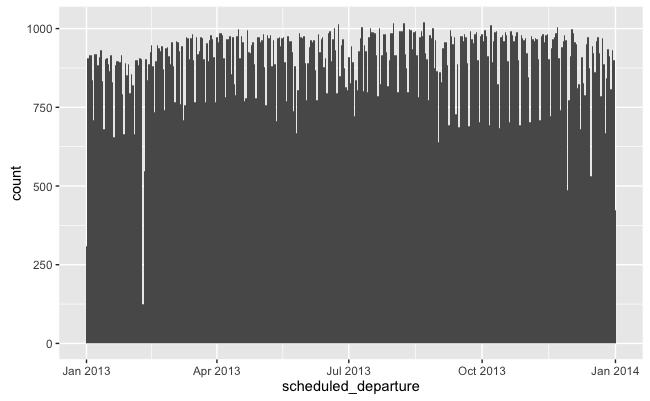

You can extract the year, month, day of the year (yday), day of the month (mday), day of the week (wday), hour, minute, second, and time zone (tz) of any date or datetime with lubridate’s accessor functions. Use the function that has the name of the unit you wish to extract.

```r
(datetime <- ymd_hms("2007-08-09 12:34:56", tz = "America/Los_Angeles"))
```

```
[1] "2007-08-09 12:34:56 PDT"
```

```
#> [1] "2007-08-09 12:34:56 PDT"
```

```r
year(datetime)
```

```
[1] 2007
```

```
#> [1] 2007
```

```r
month(datetime)
```

```
[1] 8
```

```
#> [1] 8
```

```r
yday(datetime)
```

```
[1] 221
```

```
#> [1] 221
```

```r
mday(datetime)
```

```
[1] 9
```

```
#> [1] 9
```

```r
wday(datetime)
```

```
[1] 5
```

```
#> [1] 5
```

```r
hour(datetime)
```

```
[1] 12
```

```
#> [1] 12
```

```r
minute(datetime)
```

```
[1] 34
```

```
#> [1] 34
```

```r
second(datetime)
```

```
[1] 56
```

```
#> [1] 56
```

```r
tz(datetime)
```

```
[1] "America/Los_Angeles"
```

```
#> [1] "America/Los_Angeles"
```

For both month() and wday() you can set label = TRUE to return the name of the month or day of the week. Set abbr = TRUE to return an abbreviated version of the name, which can be helpful in plots.

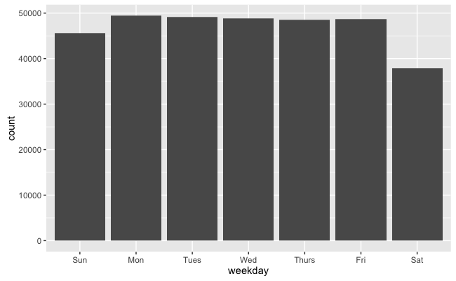

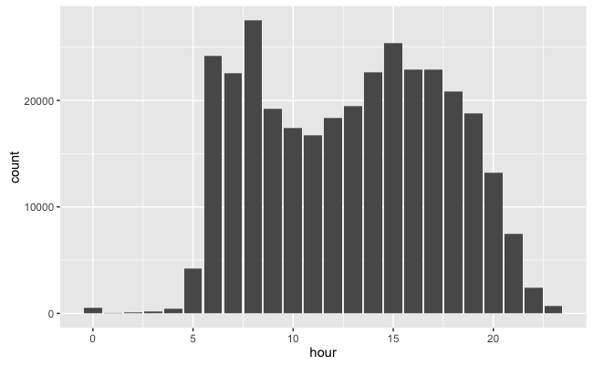

When should you depart if you want to minimize your chance of delay? The results are striking. On average, flights that left on a Saturday arrived ahead of schedule.

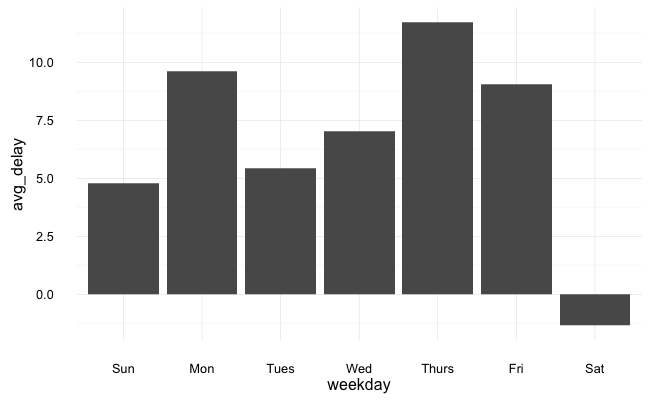

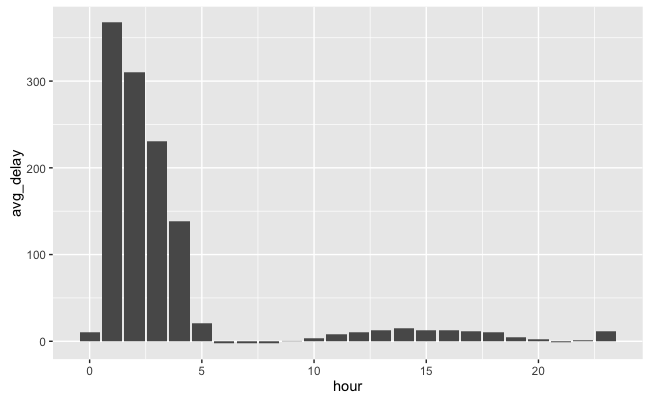

```r
datetimes %>%
  mutate(hour = hour(scheduled_departure)) %>%
  filter(!is.na(hour)) %>%
  group_by(hour) %>%
  summarise(avg_delay = mean(arr_delay, na.rm = TRUE)) %>%
  ggplot(aes(x = hour, y = avg_delay)) +
    geom_bar(stat = "identity")
```

Now, let’s try to get the average delay per month of the year

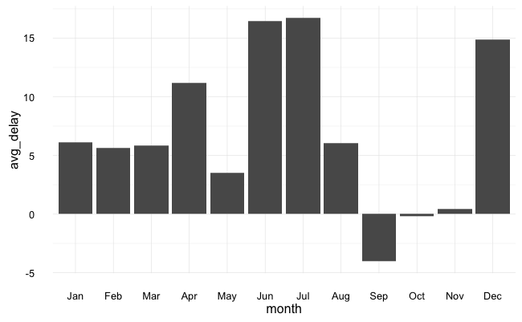